# Part I - (Prosper Loan Data)

## Introduction

> Prosper loan is a p2p lending platform, where lenders herein reffered to as investors, offer loans to borrowers. A borrower is approaved for a loan amount depending on varaibles such as, income range, prosper score, and whether or not they own a home. The data set has 113,937 rows and 81 columns.

## Preliminary Wrangling

```python
# import all packages and set plots to be embedded inline
import numpy as np
import pandas as pd
import matplotlib.pyplot as plt
import seaborn as sb

%matplotlib inline
```

> Load in your dataset and describe its properties through the questions below. Try and motivate your exploration goals through this section.

```python
# Loading the dataset
prosper_loan = pd.read_csv('prosperLoanData.csv')
```

```python
# Looking at an overview of the dataset
print(prosper_loan.shape)
print(prosper_loan.dtypes)
print(prosper_loan.info)
print(prosper_loan.head())
```

```
(113937, 81)
ListingKey                      object
ListingNumber                    int64
ListingCreationDate             object
CreditGrade                     object
Term                             int64
                                ...
PercentFunded                  float64
Recommendations                  int64
InvestmentFromFriendsCount       int64
InvestmentFromFriendsAmount    float64
Investors                        int64
Length: 81, dtype: object
<bound method DataFrame.info of                      ListingKey  ListingNumber            ListingCreationDate  \
0       1021339766868145413AB3B         193129  2007-08-26 19:09:29.263000000
1       10273602499503308B223C1        1209647  2014-02-27 08:28:07.900000000
2       0EE9337825851032864889A          81716  2007-01-05 15:00:47.090000000
3       0EF5356002482715299901A         658116  2012-10-22 11:02:35.010000000
4       0F023589499656230C5E3E2         909464  2013-09-14 18:38:39.097000000
...                         ...            ...                            ...
113932  E6D9357655724827169606C         753087  2013-04-14 05:55:02.663000000
113933  E6DB353036033497292EE43         537216  2011-11-03 20:42:55.333000000
113934  E6E13596170052029692BB1        1069178  2013-12-13 05:49:12.703000000
113935  E6EB3531504622671970D9E         539056  2011-11-14 13:18:26.597000000
113936  E6ED3600409833199F711B7        1140093  2014-01-15 09:27:37.657000000

       CreditGrade  Term              LoanStatus           ClosedDate  \
0                C    36               Completed  2009-08-14 00:00:00
1              NaN    36                 Current                  NaN
2               HR    36               Completed  2009-12-17 00:00:00
3              NaN    36                 Current                  NaN
4              NaN    36                 Current                  NaN
...            ...   ...                     ...                  ...
113932         NaN    36                 Current                  NaN
113933         NaN    36  FinalPaymentInProgress                  NaN
113934         NaN    60                 Current                  NaN
113935         NaN    60               Completed  2013-08-13 00:00:00
113936         NaN    36                 Current                  NaN

        BorrowerAPR  BorrowerRate  LenderYield  ...  LP_ServiceFees  \
```

[output cut: 80 more lines]

```
   PercentFunded  Recommendations InvestmentFromFriendsCount  \
0            1.0                0                          0
1            1.0                0                          0
2            1.0                0                          0
3            1.0                0                          0
4            1.0                0                          0

  InvestmentFromFriendsAmount Investors
0                         0.0       258
1                         0.0         1
2                         0.0        41
3                         0.0       158
4                         0.0        20

[5 rows x 81 columns]
```

```python
prosper_loan.columns
```

```
Index(['ListingKey', 'ListingNumber', 'ListingCreationDate', 'CreditGrade',
       'Term', 'LoanStatus', 'ClosedDate', 'BorrowerAPR', 'BorrowerRate',
       'LenderYield', 'EstimatedEffectiveYield', 'EstimatedLoss',
       'EstimatedReturn', 'ProsperRating (numeric)', 'ProsperRating (Alpha)',
       'ProsperScore', 'ListingCategory (numeric)', 'BorrowerState',
       'Occupation', 'EmploymentStatus', 'EmploymentStatusDuration',
       'IsBorrowerHomeowner', 'CurrentlyInGroup', 'GroupKey',
       'DateCreditPulled', 'CreditScoreRangeLower', 'CreditScoreRangeUpper',
       'FirstRecordedCreditLine', 'CurrentCreditLines', 'OpenCreditLines',
       'TotalCreditLinespast7years', 'OpenRevolvingAccounts',
       'OpenRevolvingMonthlyPayment', 'InquiriesLast6Months', 'TotalInquiries',
       'CurrentDelinquencies', 'AmountDelinquent', 'DelinquenciesLast7Years',
       'PublicRecordsLast10Years', 'PublicRecordsLast12Months',
       'RevolvingCreditBalance', 'BankcardUtilization',
       'AvailableBankcardCredit', 'TotalTrades',
       'TradesNeverDelinquent (percentage)', 'TradesOpenedLast6Months',
       'DebtToIncomeRatio', 'IncomeRange', 'IncomeVerifiable',
       'StatedMonthlyIncome', 'LoanKey', 'TotalProsperLoans',
       'TotalProsperPaymentsBilled', 'OnTimeProsperPayments',
       'ProsperPaymentsLessThanOneMonthLate',
       'ProsperPaymentsOneMonthPlusLate', 'ProsperPrincipalBorrowed',
       'ProsperPrincipalOutstanding', 'ScorexChangeAtTimeOfListing',
       'LoanCurrentDaysDelinquent', 'LoanFirstDefaultedCycleNumber',
       'LoanMonthsSinceOrigination', 'LoanNumber', 'LoanOriginalAmount',
       'LoanOriginationDate', 'LoanOriginationQuarter', 'MemberKey',
       'MonthlyLoanPayment', 'LP_CustomerPayments',
       'LP_CustomerPrincipalPayments', 'LP_InterestandFees', 'LP_ServiceFees',
       'LP_CollectionFees', 'LP_GrossPrincipalLoss', 'LP_NetPrincipalLoss',
       'LP_NonPrincipalRecoverypayments', 'PercentFunded', 'Recommendations',
       'InvestmentFromFriendsCount', 'InvestmentFromFriendsAmount',
       'Investors'],
      dtype='object')
```

```python
# Selecting only the relevant columns
col = ['Term','LoanStatus','BorrowerRate','ProsperScore','EmploymentStatus','IsBorrowerHomeowner','IncomeRange','LoanOriginalAmount','Investors']

loans = prosper_loan[col]
```

```python
#looking at the new dataset

loans.sample(10)
```

|  | Term | LoanStatus | BorrowerRate | ProsperScore | EmploymentStatus | IsBorrowerHomeowner | IncomeRange | LoanOriginalAmount | Investors |
| --- | --- | --- | --- | --- | --- | --- | --- | --- | --- |
| 38989 | 36 | Current | 0.2769 | 2.0 | Employed | False | $50,000-74,999 | 2000 | 19 |
| 92819 | 60 | Current | 0.1355 | 9.0 | Employed | False | $25,000-49,999 | 10000 | 1 |
| 45168 | 60 | Current | 0.1915 | 6.0 | Employed | True | $50,000-74,999 | 15000 | 1 |
| 70658 | 60 | Current | 0.1199 | 7.0 | Employed | True | $50,000-74,999 | 6200 | 1 |
| 62205 | 36 | Completed | 0.1299 | NaN | Full-time | True | $50,000-74,999 | 4400 | 168 |
| 12724 | 36 | Completed | 0.0745 | 9.0 | Full-time | True | $75,000-99,999 | 7000 | 252 |
| 73122 | 36 | Completed | 0.0715 | 10.0 | Full-time | True | $1-24,999 | 2000 | 84 |
| 34543 | 36 | Past Due (1-15 days) | 0.1609 | 6.0 | Part-time | True | $0 | 3000 | 67 |
| 902 | 36 | Chargedoff | 0.3500 | NaN | Full-time | True | $50,000-74,999 | 5000 | 61 |
| 7915 | 36 | Current | 0.1725 | 5.0 | Employed | False | $100,000+ | 4750 | 1 |

### What is the structure of the dataset?

The original dataset contains 113,937 rows and 81 columns. Upon visual assessment the dataset appears to be tidy with no major issues to address at first sight.

After only considering the relevant variables we require for this analysis, the current dataset now has 113,937 rows, and 9 columns.

### What is/are the main feature(s of interest in your dataset?

Our main area of interest is to ivestigate the relationship between Loan amount and the employment status and the term of the loan. Additionally, we will also find out how the borrower rate is affected by the term and amount of the loan.

### What features in the dataset do you think will help support your investigation into your features of interest?

We exepect that there will be a higher loan amount among the employed, and higher loan ampunt will have a higher loan term. Also, we expect that the borrower rate will be lower on longer loan terms and huge amount.

## Univariate Exploration

Here we will investigate the distribution of each individual variable of interest.

```python
# Convert EmploymentStatus and Loan status to ordered categorical data type
var_dict = {'EmploymentStatus': ['Employed','Full-time','Self-employed','Not available','Other','Part-time','Not employed','Retired'],
            'LoanStatus': ['Current','Completed','Chargedoff','Defaulted','Past Due (1-15 days)','Past Due (31-60 days)','Past Due (61-90 days)','Past Due (91-120 days)','Past Due (16-30 days)','FinalPaymentInProgress','Past Due (>120 days)','Cancelled'],
           'IncomeRange': ['$0','$1-24,999','$25,000-49,999','$50,000-74,999','$75,000-100,000+', 'Not displayed', 'Not employed']
           }

for var in var_dict:
    ordered_var = pd.api.types.CategoricalDtype(ordered = True, categories = var_dict[var])
    loans[var] = loans[var].astype(ordered_var)
```

### Loan Term

What is the distributionof the loan term?

```python
loans.Term.unique()
```

```
array([36, 60, 12], dtype=int64)
```

> The loan term only has three variables, 12, 36, and 60 months.

```python
# Creating a function to plot labels
def x_y_title (xaxis,yaxis,title):
    plt.xlabel(xaxis)
    plt.ylabel(yaxis)
    plt.title(title)
```

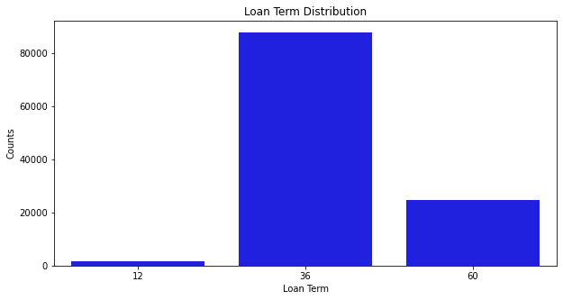

```python
# plotting the loan term distribution
plt.figure(figsize  = [10,5])

sb.countplot(data = loans, x = 'Term', color = 'blue')

# calling the labels function
x_y_title('Loan Term','Counts','Loan Term Distribution')
```

> The most preffered loan term is the 36 months with over 80,000 loans, followed by 60 months with slightly above 20,000 loans. 12 months term is the least preffered.

### Loan Status

What is the distribution of the loan status?

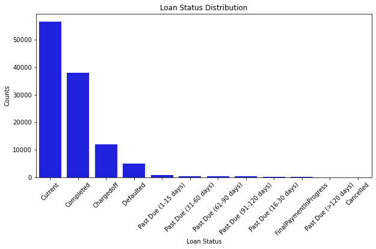

```python
#plotting the loan status distribution
plt.figure(figsize  = [10,5])

sb.countplot(data = loans, x = 'LoanStatus', color = 'blue')
plt.xticks(rotation = 45);

# Calling the label function
x_y_title('Loan Status','Counts','Loan Status Distribution')
```

> The loan status has 12 categories, out of which the current loan status has the highest number with more than 55,000 loans.

> The second most popular category is the completed status with more than 35,000 loans. With almost little to no cancelled loans.

### Borrower Rate

What is the distribution of the borrower rate?

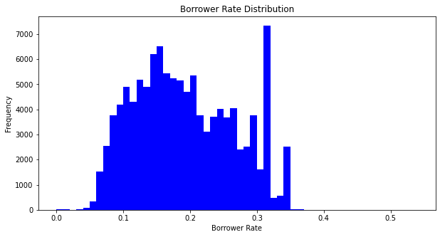

```python
bins = np.arange(0, loans.BorrowerRate.max()+0.05, 0.01)
plt.figure(figsize=[10, 5])
plt.hist(data = loans, x = 'BorrowerRate', bins = bins, color = 'blue');

#calling the labels function
x_y_title('Borrower Rate','Frequency','Borrower Rate Distribution')
```

### Prosper Rating

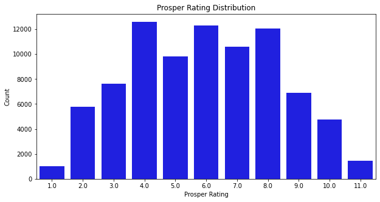

```python
plt.figure(figsize=[10, 5])
sb.countplot(data = loans, x = 'ProsperScore', color = 'blue')

#calling lables function
x_y_title('Prosper Rating','Count','Prosper Rating Distribution')
```

> Here we have a normal distribution. We can see that rating 4, 6, and 8 are the most common respectively. With a rating of 1 and 11 being the the least common respectively.

### Emoployment Status

What is the distribution of the Employment Status?

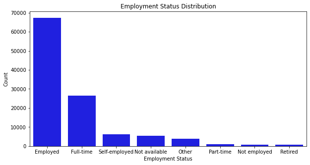

```python
plt.figure(figsize = [10,5])
sb.countplot(data = loans, x = 'EmploymentStatus', color = 'blue')

x_y_title('Employment Status','Count','Employment Status Distribution' )
```

> Prosper loans are mostly offered to users who are employed with over 65,000 loans going to the employed, while the retired and not employed get the least number of loans.

### Home Ownership

What is the distribution of home ownership?

```python
 loans.IsBorrowerHomeowner.value_counts()
```

```
True     57478
False    56459
Name: IsBorrowerHomeowner, dtype: int64
```

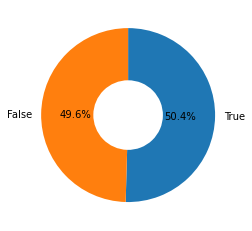

```python
home_count =  loans.IsBorrowerHomeowner.value_counts()

plt.pie(home_count, labels = home_count.index, autopct ='%1.1f%%',startangle = 90,
        counterclock = False, wedgeprops = {'width' : 0.6});
```

> Although there are more home owners, the home ownership data shows an almost equal distribution of borrowers who own a home and those who do not.

### Loan Amount

```python
np.log10(loans['LoanOriginalAmount'].describe())
```

```
count    5.056665
mean     3.921011
std      3.795588
min      3.000000
25%      3.602060
50%      3.812913
75%      4.079181
max      4.544068
Name: LoanOriginalAmount, dtype: float64
```

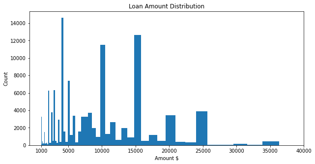

```python
plt.figure(figsize = [10,5])

bins = 10 ** np.arange(3, np.log10(loans['LoanOriginalAmount'].max()) + 0.03, 0.03)
plt.hist(data = loans, x = 'LoanOriginalAmount', bins = bins)

x_y_title('Amount $','Count','Loan Amount Distribution')

plt.xticks([1000,5000, 10000, 15000, 20000, 25000, 30000, 35000, 40000]);
```

> The loan amount distribution is multimodal, with the least amount being 1,000 and the highest amount being around 36,000.

> The most common amount borrowed is slightly below 5,000 with 14,000 loans given, followed by loan amount of 15,000 with more than 12,000 loans given.

### Income Range

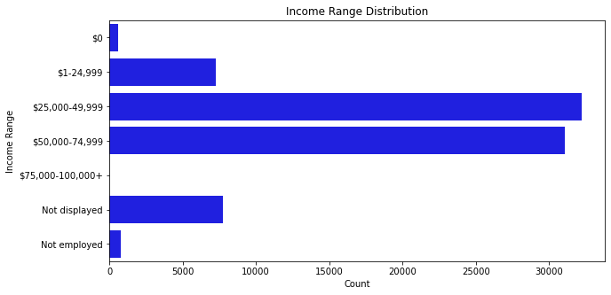

```python
plt.figure(figsize = [10,5])
sb.countplot(data = loans, y = 'IncomeRange', color = 'blue')

x_y_title('Count','Income Range','Income Range Distribution')
```

> Most of the borrowers fall under the middle income ranges of 25,000-49,000 and 50,000-74,999 with the former having the highest number of borrowers.

## Bivariate Exploration

#### What is the correlation between the numeric features?

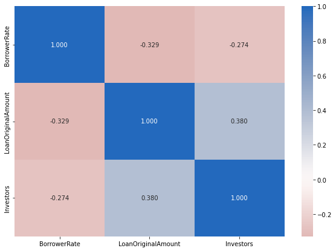

```python
# Getting the numeric features of the dataset
numeric = ['BorrowerRate','LoanOriginalAmount','Investors']

# correlation plot
plt.figure(figsize = [10, 7])
sb.heatmap(loans[numeric].corr(), annot = True, fmt = '.3f',
           cmap = 'vlag_r', center = 0);
```

> The correlatin between the Borrower rate and the loan amount is -0.329. This negative correlation confirms our hypothesis that as the loan amount increases the borrower rate is decreases.

> The correlation between the Investors and the loan amount is 0.380. This implies that as the loan amount increases even more investors will be needed to finance the loan.

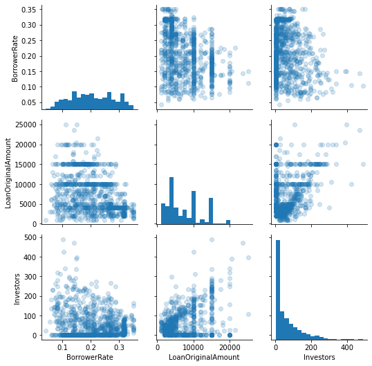

```python
# confirming these correlatons using scater plots
sample = loans.sample(2000)
g = sb.PairGrid(data = sample.dropna(), vars = numeric)
g = g.map_diag(plt.hist, bins=20)
g.map_offdiag(plt.scatter, alpha=0.2);
```

> As expected, there is a negative correletion between the borrower rate and the loan amount. The higher the loan amount the lesser the borrower rate.

> Investors and the loan amount have a positive correlation.

#### How is the prosper score related to the loan amount?

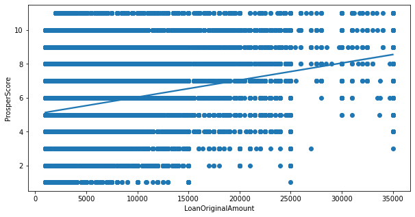

```python
plt.figure(figsize = [10, 5])
sb.regplot(data = loans, x = 'LoanOriginalAmount', y = 'ProsperScore', scatter_kws={'alpha': 1});
```

> There exist a positive correlation between the Prosper score and the loan amount. From the scatter diagram, we see that there are very few high loans (above 20,000) offered to borrowers with a lo score.

> However, as the borrower score increases, we a rise in the number of high amount loans given.

#### What relationship exists between the term and prosper core, employment satus and term, prosper rating and employment status?

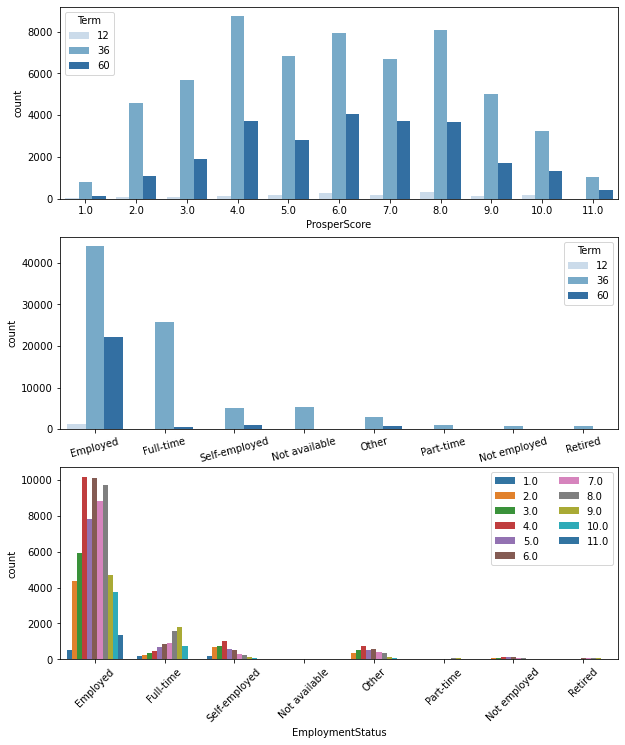

```python
plt.figure(figsize = [10, 12])

# subplot 1: Prosper score vs term
plt.subplot(3, 1, 1)
sb.countplot(data = loans, x = 'ProsperScore', hue = 'Term', palette = 'Blues')

# subplot 2: employment status vs. term
ax = plt.subplot(3, 1, 2)
sb.countplot(data = loans, x = 'EmploymentStatus', hue = 'Term', palette = 'Blues')
plt.xticks(rotation=15)

# subplot 3: Prosper rating vs. employment status, using a different color palette
ax = plt.subplot(3, 1, 3)
sb.countplot(data = loans, x = 'EmploymentStatus', hue = 'ProsperScore', palette = 'tab10')
ax.legend(loc = 1, ncol = 2); # re-arrange legend to remove overlapping
plt.xticks(rotation=45);
```

> 36 months is the term with the most number of loans, while 12 months has the least number.

> The loan term is normaly distributed against the prosper score. With high number of loans in both 36 and 60 months being between theprosper score of 4 and 8. While the extreme prosper scores have reduced number of loan count.

## Multivariate Exploration

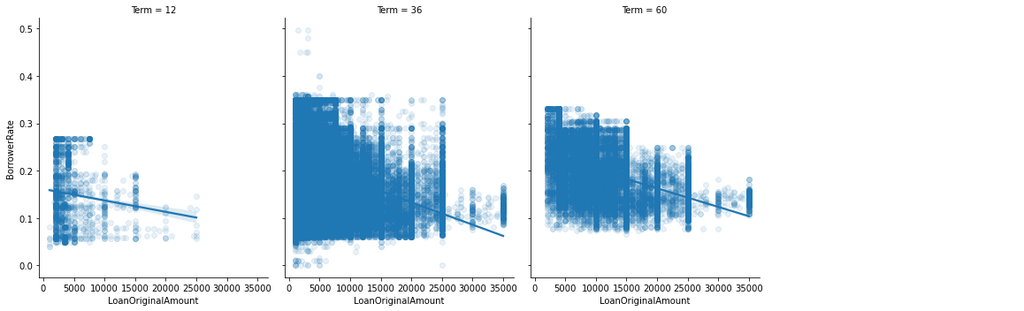

```python
# Looking at the effect of term on the relationship of Borrower rate and loan amount
g=sb.FacetGrid(data=loans, aspect=0.8, height=5, col='Term', col_wrap=4)
g.map(sb.regplot, 'LoanOriginalAmount', 'BorrowerRate', x_jitter=0.04, scatter_kws={'alpha':0.1});
g.add_legend();
```

> Term of the loan does not seem to have any different effect on the relationship between the borrower rate and the loan amount.

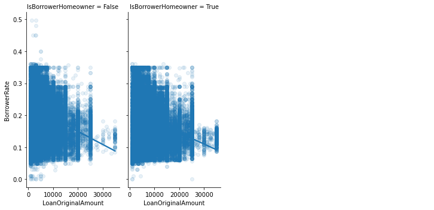

```python
g=sb.FacetGrid(data=loans, aspect=0.5, height=5, col='IsBorrowerHomeowner', col_wrap=4)
g.map(sb.regplot, 'LoanOriginalAmount', 'BorrowerRate', x_jitter=0.04, scatter_kws={'alpha':0.1});
g.add_legend();
```

> The borrower rate and the loan amount have a negative correlation. This is good and as expected.

> The higher the loan amount, the lower the borrower rate.

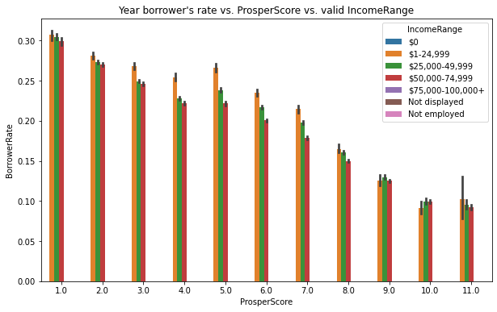

```python
plt.figure(figsize=[10, 6]);
# Removing the invalid income ranges of $0, not displayed, and not available
valid_income_range = ['$1-24,999','$25,000-49,999','$50,000-74,999','$75,000-100,000+']
new_income_range = loans.loc[loans['IncomeRange'].isin(valid_income_range)]

sb.barplot(data = new_income_range, x = 'ProsperScore', y = 'BorrowerRate', hue = 'IncomeRange');
plt.title('Year borrower\'s rate vs. ProsperScore vs. valid IncomeRange');
```

> As we can see, the lower prosper score has the higest borrower rate. This is true since, with low prosper score, the loan amount is also low, hence the high borrower rate.

> However, as the prosper score rises, the borrower rate reduces simulteneously.

### Talk about some of the relationships you observed in this part of the investigation. Were there features that strengthened each other in terms of looking at your feature(s) of interest?

> The number of iverstors also increased with an increse in the loan amount.

### Were there any interesting interactions between features?

> An intersitng interaction was between the retired borrowers and the number of loans. The retired borrowers had a near zero number of loans. With the assumption that retired borrowers have more assets compared to other borrowers, this observation came as a surprise.